# Neural Network

Giedo, Micha, Azher, Christoph

4/25/2021

# Applying a Neural Network

What we learned in this project, the computing powers of ANN’s are high and it takes time to run a model. Unfortunately, we do not have the computing power to run a model with our complete dataset. As a result, we are only going to use a subset of our initial dataset. For ANN’s the One-Hot-Encoding (OHE) mehtod is also used, which turns each category of a categorical predictor into its own binary dimension. The two steps, creating a subset and OHE are shown below.

```r
indices_subset <- createDataPartition(df.airbnbNN$log_price, p=0.01, list = FALSE)
df.subset_airbnbNN <- df.airbnbNN %>% slice(indices_subset)
dmy <- dummyVars(" ~ .", data = df.subset_airbnbNN)
df.subset_airbnbNN <- data.frame(predict(dmy, newdata = df.subset_airbnbNN))
```

## Fit a first ANN to the subset

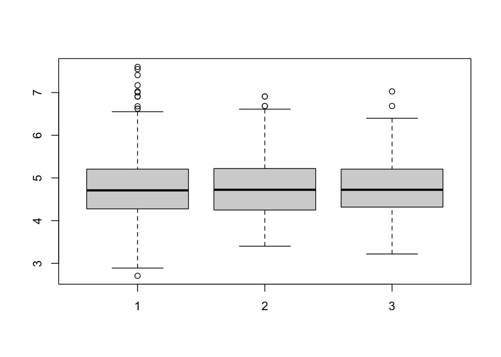

```r
set.seed(101)
indices <- createDataPartition(df.subset_airbnbNN$log_price, p = 0.8, list = FALSE)
trainNN <- df.subset_airbnbNN %>% slice(indices) # take the data labeled before as train data
testNN <- df.subset_airbnbNN %>% slice(-indices) # take the data not labeled before as test data
boxplot(trainNN$log_price, testNN$log_price, df.subset_airbnbNN %>% sample_frac(0.2) %>% pull(log_price))
```

For this model we will scale the data individually.

```r
max <- apply(df.subset_airbnbNN, 2, max)
min <- apply(df.subset_airbnbNN, 2, min)
df.subset_airbnbNN_scaled <- as.data.frame(scale(df.subset_airbnbNN, center = min, scale = max - min))
train_scaled_NN <- df.subset_airbnbNN_scaled %>% slice(indices)
test_scaled_NN <- df.subset_airbnbNN_scaled %>% slice(-indices)
```

Now we will train our first model with the ‘neuralnet’ function, this requires us to provide all the predictors we want to use. In this case, we will initially provide all the predictors we have and have a model with one node in the first layer and two nodes in the second layer. In the end, the model will be ploted.

```r
set.seed(100)
airbnbNN_net = neuralnet(log_price ~ ., train_scaled_NN, hidden = c(1,2) , linear.output = TRUE)
plot(airbnbNN_net)
```

[output not shown]

## Predict with the ANN

Let us predict the price with the trained model. For this we also need to scale back the results.

```r
pred_scaled <- compute(airbnbNN_net, test_scaled_NN)
pred <- pred_scaled$net.result * (max(df.airbnbNN$log_price) - min(df.airbnbNN$log_price)) + min(df.airbnbNN$log_price)
```

And then we can plot the results.

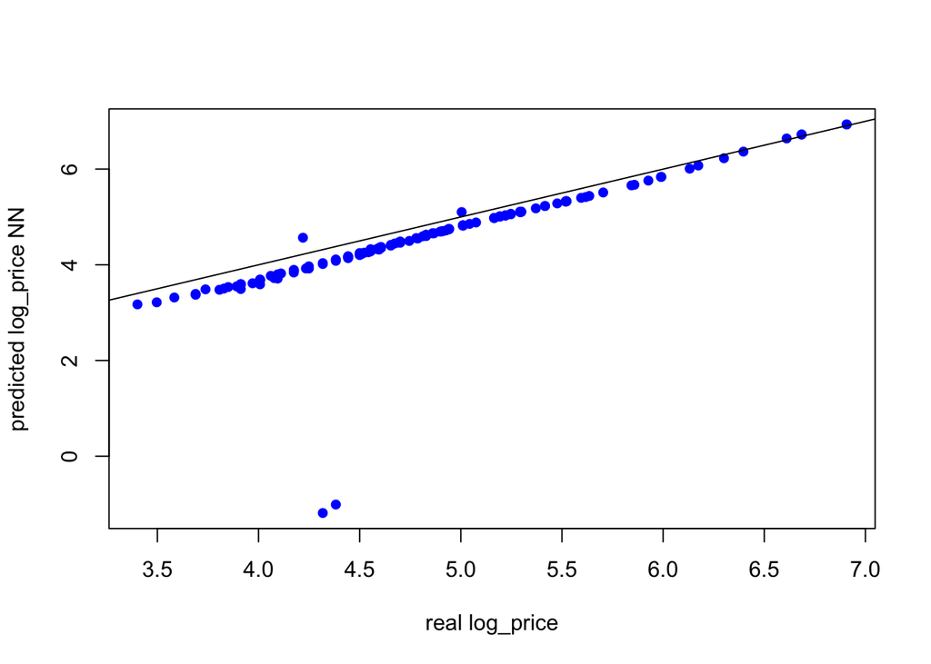

```r
plot(testNN$log_price, pred, col='blue', pch=16, ylab = "predicted log_price NN", xlab = "real log_price")
abline(0,1)
```

And then calculate the RMSE.

```r
RMSE(pred, testNN$log)
```

```
## [1] 0.6819071
```

## Cross Validation for ANN

In principle we cannot be sure that we were not simply “lucky” with the train/test split above, so the proper way to run this would be via `caret` using k-fold Cross Validation. We we run the cross validation with 3 layers, each with different amount of nodes. Our measure of fit is also the ‘RMSE’ as for all other models.

```r
set.seed(100)
tuGrid <- expand.grid(.layer1=c(1:4), .layer2=c(0:4), .layer3=c(0:1)) # define grid
trCtrl <- trainControl(
  method = 'repeatedcv', # take split of 80%
  number = 5,
  repeats = 1, # do the whole cal 5 times for
  returnResamp = 'final'
)

models <- train(
  x = df.subset_airbnbNN_scaled %>% select(-log_price),
  # scaled data with everything other than log_price
  y = df.subset_airbnbNN_scaled %>% pull(log_price),
  method = 'neuralnet', metric = 'RMSE',
  # specify the models and the metric to calculate the accuracy on
  linear.output = TRUE,
  # linear function for continuous variable
  tuneGrid = tuGrid,
  trControl = trCtrl
)
```

Now we show all the models to visually analyze which combination of nodes and layers are most accurate.

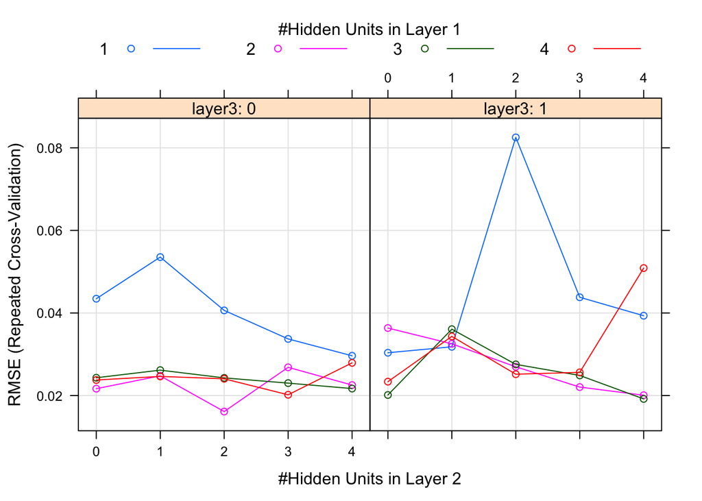

```r
plot(models)
```

```r
plot(models$finalModel)
```

[output not shown]

Now we predict the log_price again with the best model from the cross-validation, plot the results and analyze the RMSE to see if the model was actually better than the initial model.

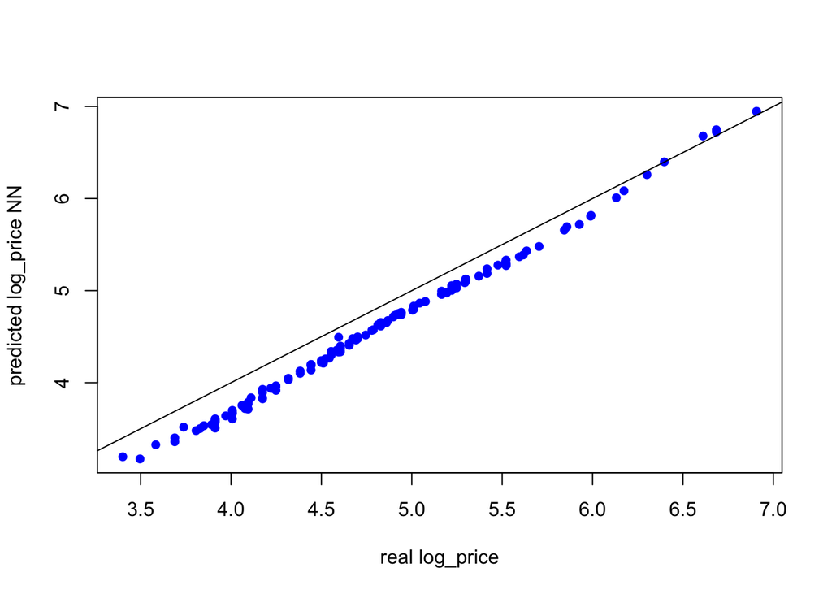

```r
pred_scaled <- compute(models$finalModel, test_scaled_NN)
pred_finalModel <- pred_scaled$net.result * (max(df.airbnbNN$log_price) - min(df.airbnbNN$log_price)) + min(df.airbnbNN$log_price)
plot(testNN$log_price, pred_finalModel, col='blue', pch=16, ylab = "predicted log_price NN", xlab = "real log_price")
abline(0,1)
```

```r
RMSE(pred_finalModel, testNN$log_price)
```

```
## [1] 0.2415828
```

The RMSE is better than our initial model, hence, we will use the second model as our final model for the ANN section.